# Lesson2_R

2023-08-18

# Lesson 2: Data wrangling basics

## Part 1: Installing and Loading Libraries

### Installing Libraries

R libraries are essential for extending its capabilities. You can install them using `install.packages()`.

```r
# Install a package
install.packages("package_name")
```

### Loading Libraries

After installation, load the package into your R session using `library()`.

```r
# Load a package
library(package_name)
```

## Part 2: Working Directory, Data Import, and Data Export

### Working Directory

You can check the current working directory using the `getwd()` function.

```r
# Check current working directory
current_dir <- getwd()
print(current_dir)
```

You can set the working directory to a specific path using the `setwd()` function.

```r
# Set working directory
new_dir <- "path/to/your/directory"
setwd(new_dir)
```

While the **`setwd()`** function changes the working directory for the current R session, you might want to change it temporarily for specific tasks.

```r
# Change working directory temporarily
old_dir <- getwd()  # Store current directory
new_dir <- "path/to/your/other/directory"
setwd(new_dir) # Set to new directory
setwd(old_dir)  # Revert to the original directory
```

### Importing Data

Use functions like `read.csv()` to import data from files like CSVs. Note, use the complete file path if the file is not within the current working directory.

```r
# Import CSV data
data <- read.csv("data.csv")
```

### Exporting Data

For exporting, use functions like `write.csv()`.

```r
# Export data to CSV
write.csv(data, "exported_data.csv", row.names = FALSE)
```

## Part 3: Writing and Calling Functions

### Writing functions

You can create custom functions to automate common tasks in your code. The general format of a function is:

```r
name <- function(argument1, argument2, argument3){

  body of the function (i.e. where you code what the function does)

  return(output)
}
```

A function takes in arguments (the example lists 3 but your function can have more or less), performs operations on the arguments, and returns an output. Here is an example of a function that computes the mean of a vector.

```r
# name of function: calculate_mean
# argument: data (a vector)
# action: compute mean
# output: mean of input vector

calculate_mean <- function(data) {
  mean_value <- sum(data) / length(data)
  return(mean_value)
}
```

### Calling your custom functions

After defining a function, you can call it with arguments.

```r
# Calling the function
data <- c(1, 2, 3, 4, 5)
result <- calculate_mean(data)
result
```

```
## [1] 3
```

### Calling functions from packages

In some cases, the actions that you want to perform on your data may already exist within a package. In these instances, you can load those packages and then call the functions within your code. For example, instead of writing a function to calculate the mean, we can just call the `mean()` function from the `stats` package (loaded by default).

```r
# Using statistical functions
mean_value <- mean(data)
mean_value
```

```
## [1] 3
```

## Part 3: Iterations (For Loops, If/Else Statements)

### For Loops

For loops allow iteration of a set of actions over a sequence of values.

```r
# For loop example
for (i in 1:5) {
  print(i)
}
```

```
## [1] 1
## [1] 2
## [1] 3
## [1] 4
## [1] 5
```

### If/Else Statements

Conditional statements help execute code based on conditions.

```r
# If/else example
x <- 10
if (x > 5) {
  print("x is greater than 5")
} else {
  print("x is not greater than 5")
}
```

```
## [1] "x is greater than 5"
```

## Part 5: Data Wrangling: Tidyverse

As mentioned previously, R is a powerful programming language that is capable of handling large datasets. When dealing with large datasets, however, it is important to stay organized and consistent. One standardized way of cleaning and organizing data in R that maps the meaning of a dataset into its structure is called **tidy data**. A whole ecosystem of R packages has been built around the tidy data principle, including `tidyverse`, `dplyr`, `tidyr` , etc.

The three main principles of tidy data are:

1. Every column is a variable (i.e. an attribute or measurement).
2. Every row is an observation (i.e. one sample).
3. Every cell is a single value.

To illustrate the principle of tidy data, please see the image below that shows two ways of visualizing the same data: wide vs long. A wide format contains values that do not repeat in the first column; a long format contains values that do repeat in the first column. Generally, the wide format is used to visualize and present data, because it is easier for our brain to interpret. However, the wide format is not considered to be **tidy data**, because each row is NOT an observation (instead each row contains the values associated with 3 observations in this example). The long format, on the other hand, is considered to be tidy data. Notice it satisfies the three main principles of tidy data. In R, it is good practice to follow the tidy data principle as it provides a systematic format for the computer to extract data and perform operations.

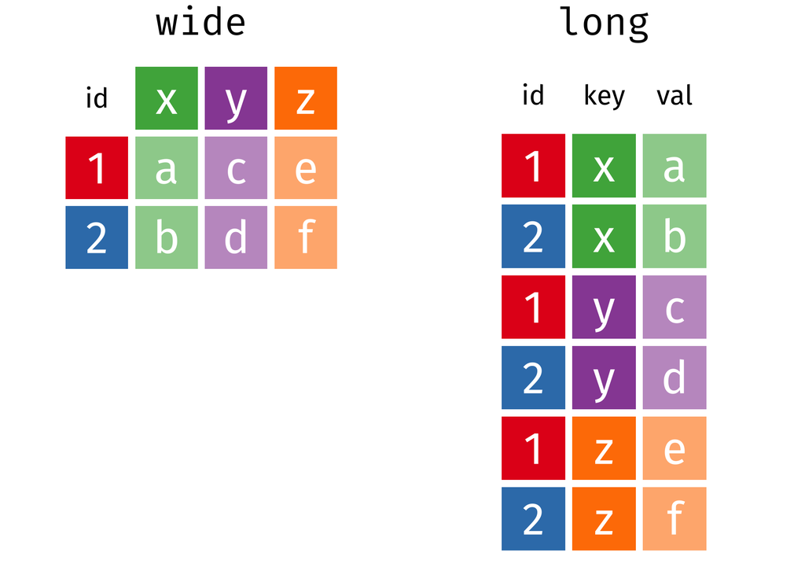

[source for [image](https://bookdown.org/martin_monkman/DataAnalyticsCodingFundamentals/tidy-data.html#:~:text=The%20%E2%80%9Cwide%E2%80%9D%20form%20doesn',in%20both%20rows%20and%20columns.)]

Due to the popularity of this way of formatting data for data science, a collection of R packages has been created that contains the core packages required for analysis. This collection is called `tidyverse`. For the rest of the lesson, we will need to install and load this library.

```
install.packages("tidyverse")
```

```r
library(tidyverse)
```

### Tibbles

Tibbles are a special type of data frame that is part of the `tidyverse` and as the name suggest, subscribes to the tidy data philosophy. One of the main differences between a tibble and a data frame is how R prints out the data. Data frames tend to print out all the rows and columns, which may be difficult to read for larger datasets; tibbles print a limited number of rows and columns by default, which makes it easier to view and understand the data. In addition, specific packages, like dplyr, has been developed to manipulate tibbles for data analysis. In general, for large datasets, it is better to use tibble.

```r
# Note, we do not need to install the tibble library since tidyverse already contains tibble, but in the future, if you want to only call the tibble package, here is the code.

# Install tibble package
install.packages("tibble")

# Load tibble package
library(tibble)
```

```r
# Create a tibble (This tibble is an example of tidy data)
gym_stats <- tibble(name = c("Alice", "Bob", "Charlie", "John", "Sarah", "Lily", "Ted"), age = c(25, 30, 90, 56, 33, 40, 16), mile_time = c(5.2, 9.8, 6.5, 12.1, 6, 7.7, 8.3))
gym_stats
```

```
## # A tibble: 7 × 3
##   name      age mile_time
##   <chr>   <dbl>     <dbl>
## 1 Alice      25       5.2
## 2 Bob        30       9.8
## 3 Charlie    90       6.5
## 4 John       56      12.1
## 5 Sarah      33       6
## 6 Lily       40       7.7
## 7 Ted        16       8.3
```

Let’s look at an example of a dataset that is not tidy and how we can convert it into tidy data.

```r
# create a tibble in wide format (this is the mile time of gym members over the course of 3 months)
# contains the gym member names, age, gym membership status (silver < gold < platinum), mile times in june, july, and august

mile_time_wide <- tibble(name = c("Alice", "Bob", "Charlie", "John", "Sarah", "Lily", "Ted"), age = c(25, 30, 90, 56, 33, 41, 16), status = c("gold", "silver", "gold", "platinum", "silver", "gold", "platinum"), june = c(5.2, 9.8, 6.5, 12.1, 6, 7.7, 8.3), july = c(5.1, 9.4, 6.9, 11, 5.5, 7.3, 8.9), august = c(5.3, 9.1, 6.4, 11.2, 5.4, 7.6, 8.7))
mile_time_wide
```

```
## # A tibble: 7 × 6
##   name      age status    june  july august
##   <chr>   <dbl> <chr>    <dbl> <dbl>  <dbl>
## 1 Alice      25 gold       5.2   5.1    5.3
## 2 Bob        30 silver     9.8   9.4    9.1
## 3 Charlie    90 gold       6.5   6.9    6.4
## 4 John       56 platinum  12.1  11     11.2
## 5 Sarah      33 silver     6     5.5    5.4
## 6 Lily       41 gold       7.7   7.3    7.6
## 7 Ted        16 platinum   8.3   8.9    8.7
```

Notice that the above data is in the wide format. Each row does not correspond with an observation; instead it is 3 observations - 3 separate mile times for each gym member. To convert the data frame from wide to long format, we only need to use one command: `pivot_longer()`. The arguments for this function are:

1. data - the data frame you want to pivot to the long format
2. cols - the columns you wish to pivot (i.e. june, july, august)
3. names_to - the name of the new column where the column names of the pivoted variables go (i.e. month)
4. values_to - the name of the new column where the data in pivoted variables go (i.e. mile_time)

```r
mile_time_long <- pivot_longer(data = mile_time_wide,
                               cols = c(june, july, august),
                               names_to = "month",
                               values_to = "mile_time")
mile_time_long
```

```
## # A tibble: 21 × 5
##    name      age status   month  mile_time
##    <chr>   <dbl> <chr>    <chr>      <dbl>
##  1 Alice      25 gold     june         5.2
##  2 Alice      25 gold     july         5.1
##  3 Alice      25 gold     august       5.3
##  4 Bob        30 silver   june         9.8
##  5 Bob        30 silver   july         9.4
##  6 Bob        30 silver   august       9.1
##  7 Charlie    90 gold     june         6.5
##  8 Charlie    90 gold     july         6.9
##  9 Charlie    90 gold     august       6.4
## 10 John       56 platinum june        12.1
## # ℹ 11 more rows
```

Convince yourself that the above data frame is in the long format!

### dplyr: a grammar for data manipulation

The `dplyr` package facilitates data manipulation with the tidy data philosophy. It can be thought of as the “grammar” of the tidyverse syntax, because it provides a set of actions or verbs that allow you to manipulate your data. The common “verbs” are:

- `arrange()`: change the order of rows
- `distinct()`: find the unique rows
- `filter()`: find rows that match the selection criteria
- `mutate()`: add new variables
- `select()`: select particular columns by name
- `slice()`: select particular rows with their indices
- `summarise()`: reduce values into a single value/summary

For the complete list, please see the [dplyr package](https://dplyr.tidyverse.org/) information.

While the number of functions/“verbs” might seem overwhelming, dplyr streamlines the usage of these verbs. In general,

1. The first argument is always the data frame that you want to analyze.
2. The subsequent arguments dictate what you want to do with that data frame (i.e. which columns you want to manipulate).
3. The output is always a new data frame.

Let’s start with a small example:

```r
# Install dplyr package (again, don't need to run this block since we already loaded tidyverse)
install.packages("dplyr")

# Load dplyr package
library(dplyr)
```

```r
# Filter rows: filter mile times based on age
filtered_mile_time <- filter(mile_time_long, age < 40)
filtered_mile_time
```

```
## # A tibble: 12 × 5
##    name    age status   month  mile_time
##    <chr> <dbl> <chr>    <chr>      <dbl>
##  1 Alice    25 gold     june         5.2
##  2 Alice    25 gold     july         5.1
##  3 Alice    25 gold     august       5.3
##  4 Bob      30 silver   june         9.8
##  5 Bob      30 silver   july         9.4
##  6 Bob      30 silver   august       9.1
##  7 Sarah    33 silver   june         6
##  8 Sarah    33 silver   july         5.5
##  9 Sarah    33 silver   august       5.4
## 10 Ted      16 platinum june         8.3
## 11 Ted      16 platinum july         8.9
## 12 Ted      16 platinum august       8.7
```

```r
# Select columns: select only age column
gym_member_age <- select(mile_time_long, name, age)
gym_member_age
```

```
## # A tibble: 21 × 2
##    name      age
##    <chr>   <dbl>
##  1 Alice      25
##  2 Alice      25
##  3 Alice      25
##  4 Bob        30
##  5 Bob        30
##  6 Bob        30
##  7 Charlie    90
##  8 Charlie    90
##  9 Charlie    90
## 10 John       56
## # ℹ 11 more rows
```

```r
# Group by and summarize: calculate the average mile time across 3 months / gym member
summary_data <- mile_time_long %>%
  group_by(name) %>%
  summarize(mean_value = mean(mile_time))
summary_data
```

```
## # A tibble: 7 × 2
##   name    mean_value
##   <chr>        <dbl>
## 1 Alice         5.2
## 2 Bob           9.43
## 3 Charlie       6.6
## 4 John         11.4
## 5 Lily          7.53
## 6 Sarah         5.63
## 7 Ted           8.63
```

### Pipes (`%>%`)

So far, we have only seen examples of doing one action on a dataframe. However, in many cases, your analysis may require multiple actions. Rather than doing the actions sequentially (which may take up a lot of memory), an easier way is to use pipes, which is a technique for passing data from one action to another. Pipes help chain operations for more readable code using the `magrittr` package. Again, this package is loaded with `tidyverse`, so we will not need to install it (code is provided in case you have to install it separately).

```r
# Install magrittr package
install.packages("magrittr")

# Load magrittr package
library(magrittr)
```

So how do you use pipes? Let’s say that we wanted to find the average mile time of the gym members across the three months who have the gold gym membership and are older than 40. To do this, we would have to do 3 separate actions that are nested:

```r
mean( mile_time_long$mile_time[mile_time_long$status == "gold" & mile_time_long$age > 40] )
```

```
## [1] 7.066667
```

This is messy and difficult to read! Using pipes, we can express this sequence of actions is a more understandable manner.

```r
# Using pipes

mile_time_long %>%
  filter(status == "gold") %>%
  filter(age > 40) %>%
  summarize(mean_value = mean(mile_time))
```

```
## # A tibble: 1 × 1
##   mean_value
##        <dbl>
## 1       7.07
```